# Reproducible Research: Peer Assessment 1

## Loading and preprocessing the data

```r
data <- read.csv("activity.csv")
data$date <- as.Date(data$date)
```

## What is mean total number of steps taken per day?

First a histogram of the total number of steps taken each day is plotted

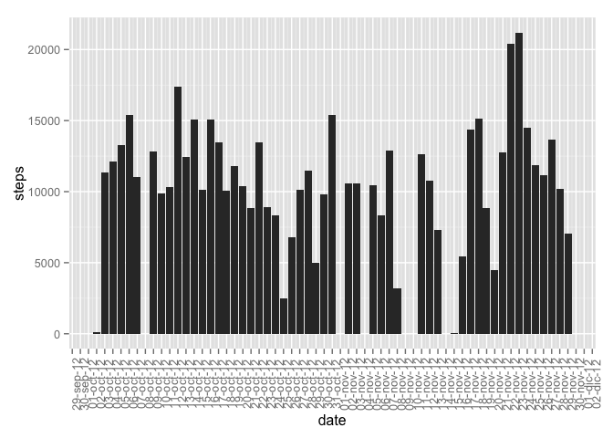

```r
library(ggplot2)
library(scales)
stepsD <- aggregate(steps~date, data = data, sum)
ggplot(stepsD, aes(x=date, y=steps))+ geom_histogram(stat = "identity")+scale_x_date(labels=date_format("%d-%b-%y"), breaks = "1 day") + theme(axis.text.x = element_text(angle=90))
```

The mean of total steps taken per day

```r
mean(stepsD$steps, na.rm = TRUE)
```

```
## [1] 10766.19
```

The median of total steps taken per day

```r
median(stepsD$steps, na.rm = TRUE)
```

```
## [1] 10765
```

## What is the average daily activity pattern?

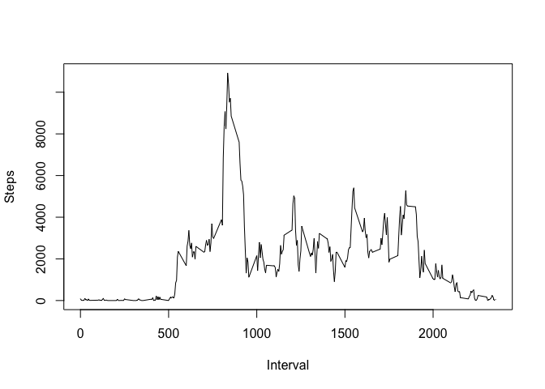

```r
stepsI <- aggregate(steps~interval, data = data, sum)
plot.ts(stepsI$interval, stepsI$steps,  type="l", xlab= "Interval", ylab= "Steps")
```

```r
colMax <- function(data) sapply(data, max, na.rm = TRUE)
interval <- colMax(stepsI)
interval[1]
```

[output not shown]

## Imputing missing values

Calculate and report the total number of missing values in the dataset

```r
sum(!complete.cases(data))
```

```
## [1] 2304
```

The strategy for filling in all of the missing values in the dataset is the mean for that 5-minute interval Create a new dataset that is equal to the original dataset but with the missing data filled in

```r
stepsM <- aggregate(steps~interval, data = data, mean)
newdataset <- data
for (i in 1:nrow(data)){
    if (is.na(newdataset[i,"steps"])){
        newdataset[i,]$steps <- stepsM[stepsM$interval==newdataset[i, "interval"],"steps"]
    }
}
```

Histogram of the total number of steps taken each day

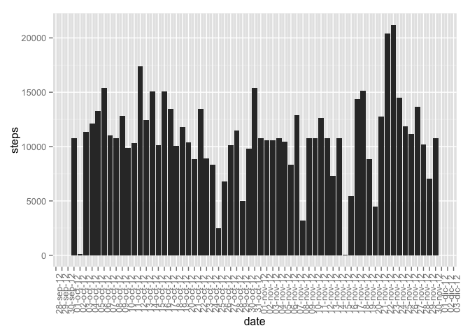

```r
nstepsD <- aggregate(steps~date, data = newdataset, sum)
ggplot(nstepsD, aes(x=date, y=steps))+ geom_histogram(stat = "identity")+scale_x_date(labels=date_format("%d-%b-%y"), breaks = "1 day") + theme(axis.text.x = element_text(angle=90))
```

The mean of total steps taken per day

```r
mean(nstepsD$steps)
```

```
## [1] 10766.19
```

The median of total steps taken per day

```r
median(nstepsD$steps)
```

```
## [1] 10766.19
```

The mean remains the same as NA are filled in with the mean of each interval. The median changes to be the same of the mean.

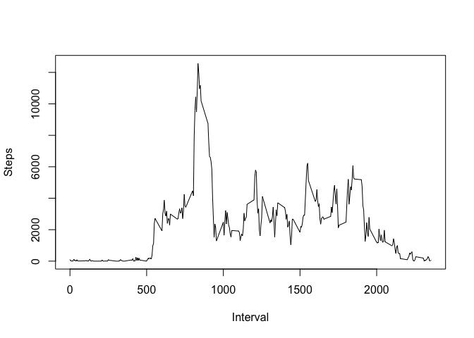

```r
nstepsI <- aggregate(steps~interval, data = newdataset, sum)
plot.ts(nstepsI$interval, nstepsI$steps,  type="l", xlab= "Interval", ylab= "Steps")
```

```r
interval <- colMax(nstepsI)
interval[1]
```

[output not shown]

## Are there differences in activity patterns between weekdays and weekends?

Create a new factor variable in the dataset with two levels – “weekday” and “weekend” indicating whether a given date is a weekday or weekend day.

```r
for (i in 1:nrow(newdataset)){
    if (weekdays(newdataset[i,"date"])== "sábado"| weekdays(newdataset[i,"date"])=="domingo"){
        newdataset[i,"daytype"] <-"weekend"
    } else {
        newdataset[i,"daytype"] <-"weekday"
    }
}
```

[figure not shown]

```r
weekenddata <- newdataset[newdataset$daytype=="weekend",]
weekdaydata <- newdataset[newdataset$daytype=="weekday",]
wenstepsM <- aggregate(steps~interval, data = newdataset, mean)
wdnstepsM <- aggregate(steps~interval, data = weekdaydata, mean)
wenstepsM$daytype <- "weekend"
wdnstepsM$daytype <- "weekday"
plotdata <- rbind(wenstepsM, wdnstepsM)
g <- ggplot(plotdata, aes(interval, steps))
g+ geom_line()+ facet_grid(daytype ~ .) + labs(x="Interval", y="Average number of steps")
```